# Analyses

Chase Latour

2024-01-02

# Description

This HTML/Rmd document will contain the analyses for the data generated for the multiple_outcomes_pregnancy R project.

# Describe Cohort

Describe the patient cohort. This will allow us to check for weird data issues.

## Read in the data

```r
# Get the directory where the Rmd file is located
rmd_directory <- dirname(rstudioapi::getSourceEditorContext()$path)

# Specify the Excel file name and path relative to the Rmd file location
data_read <- file.path(rmd_directory, "data.rds")

dataset <- readRDS(data, file = data_read)
```

## Write functions that describes the data

```r
## Identify the cohort that entered the trial

trial_cohort <- function(dataset){

  trial <- dataset %>%
    subset(trial_participant == TRUE) %>%
    # Identify the observed outcomes
    mutate(preg_outcome_final = ifelse(trt == 1,
                                       preg_outcome_final_trt,
                                       preg_outcome_final_untrt),
           preg_outcome_final_gw = ifelse(trt == 1,
                                          preg_outcome_final_gw_trt,
                                          preg_outcome_final_gw_untrt),
           preeclampsia = ifelse(trt == 1,
                                 preeclampsia_trt,
                                 preeclampsia_untrt),
           sga = ifelse(trt == 1,
                        sga_trt,
                        sga_untrt)) %>%
    rowwise() %>%
    mutate(censor = ifelse(first_censoring_gw < preg_outcome_final_gw & !is.na(first_censoring_gw),
                      1,
                      0),
           time = ifelse(censor == 1,
                         first_censoring_gw,
                         preg_outcome_final_gw)
           ) %>%
    ungroup() %>%
    mutate(
      composite_km = case_when(censor == 1 ~ 0,
                          preg_outcome_final == "fetaldeath" & censor == 0 ~ 1,
                          preg_outcome_final == "livebirth" & censor == 0 & preeclampsia == 1 ~ 1,
                          preg_outcome_final == "livebirth" & censor == 0 & preeclampsia == 0 ~ 0),
      composite_multi = case_when(censor == 1 ~ 0,
                                censor == 0 & preg_outcome_final == "fetaldeath" ~ 1,
                                censor == 0 & preeclampsia == 1 ~ 1,
                                censor == 0 & preg_outcome_final == "livebirth" & preeclampsia == 0 ~ 2
                                ),
      # Make a gestational week variable for the composite_multi variable
      composite_multi_gw = ifelse(censor == 1,
                                  first_censoring_gw,
                                  preg_outcome_final_gw),
      # Make composite variable that ignores censoring
      composite_no_censor = ifelse(preg_outcome_final == "fetaldeath" |
                                     (preg_outcome_final == "livebirth" & preeclampsia == 1),
                                   1,
                                   0),
      # Make a SGA variable for the KM estimator
      sga_km = ifelse(sga == 1 & censor == 0,
                    1,
                    0),
      # Make SGA variables with fetal death only as a competing event
      sga_multi_do = case_when(censor == 1 ~ 0,
                          censor == 0 & sga == 1 ~ 1,
                          censor == 0 & preg_outcome_final == "fetaldeath" ~ 2,
                          censor == 0 & sga == 0 & preg_outcome_final == "livebirth" ~ 0),
      # Make a gestational week variable for the sga_multi variable
      sga_multi_do_gw = ifelse(censor == 1,
                                  first_censoring_gw,
                                  preg_outcome_final_gw),
      # Make SGA variables with all competing events
      sga_multi_all = case_when(censor == 1 ~ 0,
                                censor == 0 & sga == 1 ~ 1,
                                censor == 0 & preg_outcome_final == "fetaldeath" ~ 2,
                                censor == 0 & sga == 0 & preg_outcome_final == "livebirth" ~ 2),
      # COULD BE 3 - COME BACK
      # Make a gestational week variable for the sga_multi variable
      sga_multi_all_gw = ifelse(censor == 1,
                                  first_censoring_gw,
                                  preg_outcome_final_gw),
      # Make a SGA variable that ignores censoring
      sga_no_censor = ifelse(sga == 1, 1, 0),

      # PReterm KM variables
      preterm_km = ifelse(preg_outcome_final_gw < 35 & censor == 0 &
                          preg_outcome_final == "livebirth", # Previously 37
                          1,
                          0),
      preterm_t = ifelse(preterm_km == 1, preg_outcome_final_gw,
                         ifelse(preterm_km == 0 & time >= 35, 35,
                                time)),
      # Preterm AJ variables - NEED TO CHECK
      preterm_multi = case_when(time >= 35 ~ 0,
                                censor == 1 & time < 35 ~ 0,
                                censor == 0 & preg_outcome_final == "livebirth" & time < 35 ~ 1,
                                censor == 0 & preg_outcome_final == "fetaldeath" & time < 35 ~ 2),
      preterm_multi_gw = ifelse(time >= 35, 35, time),
      # Make a preterm variable that ignores censoring
      preterm_no_censor = ifelse(preg_outcome_final == "livebirth" & preg_outcome_final_gw < 35,
                                 1,
                                 0)

    )

  return(trial)

}




### Calculate the number of trial participants

total_trial <- function(dataset){

  tib <- dataset %>%
    summarize(count = n())

  return(as.double(tib[1,1]))

}

## Count the number of patients across treatment groups
## -- Will save this as a tibble

total_trial_trt <- function(dataset){

  tib <- dataset %>%
    group_by(trt) %>%
    summarize(count = n(),
              percent = round(count / nrow(dataset) * 100),2)

  return(tib)

}

## Describe indexing into the cohort

trial_index <- function(dataset){

  tib <- dataset %>%
    group_by(trt) %>%
    summarize(
              min = min(first_index),
              p25 = quantile(first_index, 0.25),
              median = median(first_index),
              p75 = quantile (first_index, 0.75),
              max = max(first_index),
              nmiss = sum(is.na(first_index))
              )

  return(tib)

}

## Number of live births and fetal deaths across treatment groups
## -- Currently, this does not consider censoring.
count_outcomes <- function(dataset){

  tib <- dataset %>%
    group_by(trt) %>%
    summarize(fetal_death = sum(preg_outcome_final == 'fetaldeath'),
              fd_percent = round(fetal_death / n() * 100,1),
              livebirth = sum(preg_outcome_final == 'livebirth'),
              lb_percent = round(livebirth / n() * 100,1))

  return(tib)

}

## Distribution of pregnancy outcomes
## -- Currently, this does not consider censoring.
outcomes_dist <- function(dataset){

  tib <- dataset %>%
    group_by(trt, preg_outcome_final) %>%
    summarize(
              min = min(preg_outcome_final_gw),
              p25 = quantile(preg_outcome_final_gw, 0.25),
              median = median(preg_outcome_final_gw),
              p75 = quantile (preg_outcome_final_gw, 0.75),
              max = max(preg_outcome_final_gw),
              .groups = 'keep'
              )

  return(tib)

}

## Number with preeclampsia and SGA
count_p_s <- function(dataset){

  tib <- dataset %>%
    group_by(trt) %>%
    summarize(preeclampsia = sum(preeclampsia == 1),
              preec_perc = round(preeclampsia / n() * 100, 1),
              sga = sum(sga == 1),
              sga_perc = round(sga / n() * 100, 1))

  return(tib)

}

## KM Estimator
## -- Code for function that uses the Kaplan-Meier estimator to estimate risk.

km_estimator <- function(dataset, outcome_var, outcome_var_t, t_val){

  ## Run the KM analysis only considering the composite outcome.
  km <- survfit(Surv(get(outcome_var_t), get(outcome_var)) ~ trt, data = dataset)

  wrisk <- data.frame(t = km$time, s = km$surv, r = 1 - km$surv, #se = km$std.err,
                          trt = c(rep(0, km$strata["trt=0"]), rep(1, km$strata["trt=1"])))

  estimate <- wrisk %>%
    filter(t < t_val+0.5) %>% # Deal with no additional risk scenarios
    group_by(trt) %>%
    summarize(r = last(r),
              #se = last(se),
              .groups = 'drop') %>%
    pivot_wider(names_from = trt,
                values_from = c(r), #, se
                names_glue = "{.value}_{trt}") %>%
    rowwise() %>%
    mutate(rr = r_1/r_0,
           rd = r_1 - r_0,
           Estimator = "Kaplan-Meier") %>%
    select(r_0, r_1, rr, #RR_lower, RR_upper,
           rd #,
           #RD_lower, RD_upper
           )

  return(estimate)

}


## AJ Estimator

aj_estimator <- function(dataset, outcome_var, outcome_var_t, t_val){

  #jitter ties
  #set.seed(1234)
  # Not sure if should set seed for jittering outcomes
  dataset2 <- dataset %>%
    group_by(get(outcome_var_t)) %>%
    add_tally() %>%
    ungroup() %>%
    mutate(
      # Jitter event times
      jitter = runif(nrow(dataset), min = -.01, max = .01), # N in the samp
      time = ifelse(n>1, get(outcome_var_t) + jitter, get(outcome_var_t))
      )

  # Run the AJ model
  aj <- survfit(Surv(time, factor(get(outcome_var))) ~ trt, data = dataset2)

  mod <- summary(aj)

  summod <- data.frame(t = mod$time,
                       r = mod$pstate[,2],
                       #se = mod$std.err[,2],
                       # This is not right yet
                       #trt = c(rep(0, mod$strata["trt=0"]), rep(1, mod$strata["trt=1"]))
                       trt = c(rep(0, length(mod[["strata"]][mod[["strata"]] == "trt=0"])),
                                   rep(1, length(mod[["strata"]][mod[["strata"]] == "trt=1"])))
                       ) %>%
    filter(t < t_val+0.5) %>%  # Deal with the jittering of outcomes
    group_by(trt) %>%
    summarize(r = last(r),
              #se = last(se),
              .groups = 'drop') %>%
    pivot_wider(names_from = trt,
                values_from = c(r), #, se
                names_glue = "{.value}_{trt}") %>%
    rowwise() %>%
    mutate(rr = r_1/r_0,
           rd = r_1 - r_0,
           Estimator = "Aalen-Johanssen") %>%
    select(r_0, r_1, rr, #RR_lower, RR_upper,
           rd #,
           #RD_lower, RD_upper
           )

  return(summod)


}

## Create a function that calculates the RD and RR that we would have
## -- expected without censoring. This should provide the
## -- correct estimate for the trial and give a sense of how
## -- informative the censoring process is.

no_censor_estimator <- function(dataset, outcome_var){

  summary <- dataset %>%
    group_by(trt) %>%
    summarize(r = sum(get(outcome_var) == 1) / n(),
              .groups = "drop") %>%
    pivot_wider(names_from = trt,
                values_from = r,
                names_glue = "{.value}_{trt}") %>%
    rowwise() %>%
    mutate(rr = r_1 / r_0,
           rd = r_1 - r_0)

  return(summary)

}
```

## Clean data and conduct analyses

```r
trial <- dataset %>%
  bind_rows() %>%
  nest(data = c(-sim_id)) %>%
  mutate(trial_cohort = purrr::map(data, ~trial_cohort(.x)),
         trial_n = purrr::map(trial_cohort, ~total_trial(.x)),
         trial_n_trt = purrr::map(trial_cohort, ~total_trial_trt(.x)),
         trial_indices = purrr::map(trial_cohort, ~trial_index(.x)),
         trial_outcomes = purrr::map(trial_cohort, ~count_outcomes(.x)),
         trial_outcomes_dist = purrr::map(trial_cohort, ~outcomes_dist(.x)),
         trial_pre_sga = purrr::map(trial_cohort, ~count_p_s(.x)),

         ## Calculate RRs and risks for composite outcome
         km_composite = purrr::map(trial_cohort, ~km_estimator(.x, outcome_var = "composite_km",
                                                               outcome_var_t = "time", t_val = 41) %>%
                                     rename_all(~ paste("km_composite_", .))),
         aj_composite = purrr::map(trial_cohort, ~aj_estimator(.x, "composite_multi",
                                                               "composite_multi_gw", 41) %>%
                                     rename_all(~ paste("aj_composite_", .))),
         no_censor_composite = purrr::map(trial_cohort, ~no_censor_estimator(.x, outcome_var = "composite_no_censor") %>%
                                            rename_all(~ paste("no_censor_composite_", .))),

         ## Calculate RRs and risks for SGA outcome
         # km_sga = purrr::map(trial_cohort, ~km_estimator(.x, outcome_var = "sga_km",
         #                                                       outcome_var_t = "time", t_val = 41) %>%
         #                             rename_all(~ paste("km_sga_", .))),
         km_sga_fd = purrr::map(trial_cohort, ~km_estimator(.x, outcome_var = "sga_km",
                                                            outcome_var_t = "time", t_val = 41) %>%
                                  rename_all(~ paste("km_sga_fd_", .))),
         aj_sga_fd = purrr::map(trial_cohort, ~aj_estimator(.x, "sga_multi_do",
                                                               "sga_multi_do_gw", 41) %>%
                                     rename_all(~ paste("aj_sga_fd_", .))),
         no_censor_sga_fd = purrr::map(trial_cohort, ~no_censor_estimator(.x,
                                                                          outcome_var = "sga_no_censor") %>%
                                            rename_all(~ paste("no_censor_sga_fd_", .))),
         km_sga_all = purrr::map(trial_cohort, ~km_estimator(.x, outcome_var = "sga_km",
                                                             outcome_var_t = "time", t_val = 41) %>%
                                   rename_all(~ paste("km_sga_all_", .))),
         aj_sga_all = purrr::map(trial_cohort, ~aj_estimator(.x, "sga_multi_all",
                                                               "sga_multi_all_gw", 41) %>%
                                     rename_all(~ paste("aj_sga_all_", .))),
         no_censor_sga_all = purrr::map(trial_cohort, ~no_censor_estimator(.x,
                                                                           outcome_var = "sga_no_censor") %>%
                                            rename_all(~ paste("no_censor_sga_all_", .))),
         # no_censor_sga = purrr::map(trial_cohort, ~no_censor_estimator(.x, outcome_var = "sga_no_censor") %>%
         #                                    rename_all(~ paste("no_censor_sga_", .))),

         ## Calculate RRs and risks for preterm live birth as outcome
         km_preterm = purrr::map(trial_cohort, ~km_estimator(.x, outcome_var = "preterm_km",
                                                               outcome_var_t = "preterm_t", t_val = 34) %>%
                                     rename_all(~ paste("km_preterm_", .))),
         aj_preterm = purrr::map(trial_cohort, ~aj_estimator(.x, "preterm_multi",
                                                               "preterm_multi_gw", 41) %>%
                                     rename_all(~ paste("aj_preterm_", .))),
         no_censor_preterm = purrr::map(trial_cohort, ~no_censor_estimator(.x, outcome_var = "preterm_no_censor") %>%
                                          rename_all(~ paste("no_censor_preterm_", .)))

         ) %>%
  unnest_wider(c(km_composite, aj_composite, no_censor_composite, km_sga_fd, aj_sga_fd, km_sga_all,
                 aj_sga_all, #no_censor_sga,
                 no_censor_sga_fd, no_censor_sga_all,
                 km_preterm, aj_preterm, no_censor_preterm))

## Everything seems to work as expected, though should compare results from original to new
```

# Conduct Analyses

We want to understand the difference in the risk, risk ratio, and risk difference estimates from each analytic approach. This will include the following calculations:

- Risk(Outcome|Treated) via KM - Risk(Outcome|Treated) without Censoring
- Risk(Outcome|Untreated) via KM - Risk(Outcome|Untreated) without Censoring
- Risk(Outcome|Treated) via AJ - Risk(Outcome|Treated) without Censoring
- Risk(Outcome|Untreated) via AJ - Risk(Outcome|Untreated) without Censoring
- Log(RR) via KM - Log(RR) without Censoring
- Log(RR) via Aj - Log(RR) without Censoring
- RD via KM - RD without Censoring
- RD via AJ - RD without Censoring

```r
bias_outcome <- function(r1_km, r0_km, r1_nocen, r0_nocen, r1_aj, r0_aj,
                         rr_km, rr_nocen, rr_aj,
                         rd_km, rd_nocen, rd_aj, prefix = ""){

  dataset <- tibble(
    risk1_km_nocen = r1_km - r1_nocen,
    risk0_km_nocen = r0_km - r0_nocen,
    risk1_aj_nocen = r1_aj - r1_nocen,
    risk0_aj_nocen = r0_aj - r0_nocen,
    rr_km_nocen = log(rr_km) - log(rr_nocen),
    rr_aj_nocen = log(rr_aj) - log(rr_nocen),
    rd_km_nocen = rd_km - rd_nocen,
    rd_aj_nocen = rd_aj - rd_nocen
  )

  dataset <- dataset %>%
    rename_all(~paste0(prefix, .))

  return(dataset)

}



trial2 <- trial %>%
  rowwise() %>%
  mutate(
    composite = list(bias_outcome(`km_composite_ r_1`, `km_composite_ r_0`, `no_censor_composite_ r_1`,
                             `no_censor_composite_ r_0`, `aj_composite_ r_1`, `aj_composite_ r_0`,
                             `km_composite_ rr`, `no_censor_composite_ rr`, `aj_composite_ rr`,
                             `km_composite_ rd`, `no_censor_composite_ rd`, `aj_composite_ rd`, "composite_")),
    sga_fd = list(bias_outcome(`km_sga_fd_ r_1`, `km_sga_fd_ r_0`, `no_censor_sga_fd_ r_1`,
                               `no_censor_sga_fd_ r_0`,
                               `aj_sga_fd_ r_1`, `aj_sga_fd_ r_0`,
                               `km_sga_fd_ rr`, `no_censor_sga_fd_ rr`, `aj_sga_fd_ rr`,
                               `km_sga_fd_ rd`, `no_censor_sga_fd_ rd`, `aj_sga_fd_ rd`, "sga_fd_")),
    sga_all = list(bias_outcome(`km_sga_all_ r_1`, `km_sga_all_ r_0`, `no_censor_sga_all_ r_1`,
                                `no_censor_sga_all_ r_0`, `aj_sga_all_ r_1`, `aj_sga_all_ r_0`,
                               `km_sga_all_ rr`, `no_censor_sga_all_ rr`, `aj_sga_all_ rr`,
                               `km_sga_all_ rd`, `no_censor_sga_all_ rd`, `aj_sga_all_ rd`, "sga_all_")),
    preterm = list(bias_outcome(`km_preterm_ r_1`, `km_preterm_ r_0`, `no_censor_preterm_ r_1`,
                                `no_censor_preterm_ r_0`, `aj_preterm_ r_1`, `aj_preterm_ r_0`,
                                `km_preterm_ rr`, `no_censor_preterm_ rr`, `aj_preterm_ rr`,
                                `km_preterm_ rd`, `no_censor_preterm_ rd`, `aj_preterm_ rd`, "preterm_"))
  ) %>%
  unnest(c(composite, sga_fd, sga_all, preterm))
```

## Calculate RRs and RDs

These are calculated across the simulated cohorts with the point estimate calculated as the mean, and the standard error of the estimate across cohorts used for confidence intervals.

We will calculate this for all three ways of analyzing the data.

```r
# Function that outputs the RR and RD estimates for each of the analytic approaches.

## Dynamic column names -- OLD
# outcome_rr_rd <- function(dataset, outcome_var){
#
#   z <- qnorm(0.975)
#
#   data2 <- dataset %>%
#     ungroup() %>%
#     summarize(
#
#       outcome = outcome_var,
#
#       ##########
#       ## Composite outcome
#       ##########
#
#       ### KM Estimates
#       ### -- RR
#       !!paste0("rr_", outcome_var, "_km") := exp(mean(log(!!sym(paste0("km_", outcome_var, "_ rr"))))),
#       !!paste0("rr_", outcome_var, "_km_var") := var(log(!!sym(paste0("km_", outcome_var, "_ rr")))),
#       !!paste0("rr_", outcome_var, "_km_lcl") := exp(log(!!sym(paste0("rr_", outcome_var, "_km"))) -
#                                                        z * sqrt(!!sym(paste0("rr_", outcome_var, "_km_var"))
#                                                                 / n())),
#       !!paste0("rr_", outcome_var, "_km_ucl") := exp(log(!!sym(paste0("rr_", outcome_var, "_km"))) +
#                                                        z * sqrt(!!sym(paste0("rr_", outcome_var, "_km_var"))
#                                                                 / n())),
#       ### -- RD
#       !!paste0("rd_", outcome_var, "_km") := mean(!!sym(paste0("km_", outcome_var, "_ rd"))),
#       !!paste0("rd_", outcome_var, "_km_var") := var(!!sym(paste0("km_", outcome_var, "_ rd"))),
#       !!paste0("rd_", outcome_var, "_km_lcl") := !!sym(paste0("rd_", outcome_var, "_km")) -
#         z * sqrt(!!sym(paste0("rd_", outcome_var, "_km_var"))
#                  / n()),
#       !!paste0("rd_", outcome_var, "_km_ucl") := !!sym(paste0("rd_", outcome_var, "_km")) +
#         z * sqrt(!!sym(paste0("rd_", outcome_var, "_km_var"))
#                  / n()),
#
#       ### AJ Estimates
#       ### -- RR
#       !!paste0("rr_", outcome_var, "_aj") := exp(mean(log(!!sym(paste0("aj_", outcome_var, "_ rr"))))),
#       !!paste0("rr_", outcome_var, "_aj_var") := var(log(!!sym(paste0("aj_", outcome_var, "_ rr")))),
#       !!paste0("rr_", outcome_var, "_aj_lcl") := exp(log(!!sym(paste0("rr_", outcome_var, "_aj")))
#                                                      - z * sqrt(!!sym(paste0("rr_", outcome_var, "_aj_var"))
#                                                                 / n())),
#       !!paste0("rr_", outcome_var, "_aj_ucl") := exp(log(!!sym(paste0("rr_", outcome_var, "_aj")))
#                                                      + z * sqrt(!!sym(paste0("rr_", outcome_var, "_aj_var"))
#                                                                 / n())),
#       ### -- RD
#       !!paste0("rd_", outcome_var, "_aj") := mean(!!sym(paste0("aj_", outcome_var, "_ rd"))),
#       !!paste0("rd_", outcome_var, "_aj_var") := var(!!sym(paste0("aj_", outcome_var, "_ rd"))),
#       !!paste0("rd_", outcome_var, "_aj_lcl") := !!sym(paste0("rd_", outcome_var, "_aj"))
#       - z * sqrt(!!sym(paste0("rd_", outcome_var, "_aj_var"))
#                  / n()),
#       !!paste0("rd_", outcome_var, "_aj_ucl") := !!sym(paste0("rd_", outcome_var, "_aj"))
#       + z * sqrt(!!sym(paste0("rd_", outcome_var, "_aj_var"))
#                  / n()),
#
#       ### No Censoring Estimates
#       ### -- RR
#       !!paste0("rr_", outcome_var, "_nocen") := exp(mean(log(!!sym(paste0("no_censor_",
#                                                                           outcome_var, "_ rr"))))),
#       !!paste0("rr_", outcome_var, "_nocen_var") := var(log(!!sym(paste0("no_censor_",
#                                                                          outcome_var, "_ rr")))),
#       !!paste0("rr_", outcome_var, "_nocen_lcl") := exp(log(!!sym(paste0("rr_",
#                                                                          outcome_var, "_nocen")))
#                                                         - z * sqrt(!!sym(paste0("rr_",
#                                                                                 outcome_var, "_nocen_var"))
#                                                                    / n())),
#       !!paste0("rr_", outcome_var, "_nocen_ucl") := exp(log(!!sym(paste0("rr_",
#                                                                          outcome_var, "_nocen")))
#                                                         + z * sqrt(!!sym(paste0("rr_",
#                                                                                 outcome_var, "_nocen_var"))
#                                                                    / n())),
#       ### -- RD
#       !!paste0("rd_", outcome_var, "_nocen") := mean(!!sym(paste0("no_censor_", outcome_var, "_ rd"))),
#       !!paste0("rd_", outcome_var, "_nocen_var") := var(!!sym(paste0("no_censor_", outcome_var, "_ rd"))),
#       !!paste0("rd_", outcome_var, "_nocen_lcl") := !!sym(paste0("rd_", outcome_var, "_nocen"))
#       - z * sqrt(!!sym(paste0("rd_", outcome_var, "_nocen_var"))
#                  / n()),
#       !!paste0("rd_", outcome_var, "_nocen_ucl") := !!sym(paste0("rd_", outcome_var, "_nocen"))
#       + z * sqrt(!!sym(paste0("rd_", outcome_var, "_nocen_var"))
#                  / n())
#
#     )
#
#   return(data2)
#
# }

outcome_rr_rd <- function(dataset, outcome_var){

  z <- qnorm(0.975)

  data2 <- dataset %>%
    ungroup() %>%
    summarize(

      outcome = outcome_var,

      ##########
      ## Composite outcome
      ##########

      ### KM Estimates
      ### -- RR
      rr_km = exp(mean(log(!!sym(paste0("km_", outcome_var, "_ rr"))))),
      rr_km_var = var(log(!!sym(paste0("km_", outcome_var, "_ rr")))),
      rr_km_lcl = exp(log(rr_km) - z * sqrt(rr_km_var / n())),
      rr_km_ucl = exp(log(rr_km) + z * sqrt(rr_km_var / n())),
      ### -- RD
      rd_km = mean(!!sym(paste0("km_", outcome_var, "_ rd"))),
      rd_km_var := var(!!sym(paste0("km_", outcome_var, "_ rd"))),
      rd_km_lcl := rd_km - z * sqrt(rd_km_var / n()),
      rd_km_ucl := rd_km + z * sqrt(rd_km_var / n()),

      ### AJ Estimates
      ### -- RR
      rr_aj := exp(mean(log(!!sym(paste0("aj_", outcome_var, "_ rr"))))),
      rr_aj_var := var(log(!!sym(paste0("aj_", outcome_var, "_ rr")))),
      rr_aj_lcl := exp(log(rr_aj) - z * sqrt(rr_aj_var / n())),
      rr_aj_ucl := exp(log(rr_aj) + z * sqrt(rr_aj_var / n())),
      ### -- RD
      rd_aj := mean(!!sym(paste0("aj_", outcome_var, "_ rd"))),
      rd_aj_var := var(!!sym(paste0("aj_", outcome_var, "_ rd"))),
      rd_aj_lcl := rd_aj - z * sqrt(rd_aj_var / n()),
      rd_aj_ucl := rd_aj + z * sqrt(rd_aj_var / n()),

      ### No Censoring Estimates
      ### -- RR
      rr_nocen := exp(mean(log(!!sym(paste0("no_censor_", outcome_var, "_ rr"))))),
      rr_nocen_var := var(log(!!sym(paste0("no_censor_", outcome_var, "_ rr")))),
      rr_nocen_lcl := exp(log(rr_nocen) - z * sqrt(rr_nocen_var / n())),
      rr_nocen_ucl := exp(log(rr_nocen) + z * sqrt(rr_nocen_var / n())),
      ### -- RD
      rd_nocen := mean(!!sym(paste0("no_censor_", outcome_var, "_ rd"))),
      rd_nocen_var := var(!!sym(paste0("no_censor_", outcome_var, "_ rd"))),
      rd_nocen_lcl := rd_nocen - z * sqrt(rd_nocen_var / n()),
      rd_nocen_ucl := rd_nocen + z * sqrt(rd_nocen_var / n())

    )

  return(data2)

}


# Make a dataset with RRs and RDs for each of the outcomes.
composite <- outcome_rr_rd(trial2, "composite")
sga_fd <- outcome_rr_rd(trial2, "sga_fd")
sga_all <- outcome_rr_rd(trial2, "sga_all")
preterm <- outcome_rr_rd(trial2, "preterm")

# Stack these datasets
rr_and_rd <- rbind(composite, sga_fd) %>%
  rbind(sga_all) %>%
  rbind(preterm)
```

## Plot and Print

### RRs

Use density ridges to illustrate the distribution of the RR estimates. In all RR plots, the x-axis, with the RRs is log-scaled.

Below, is the code for the plotting function.

```r
# Clean up the dataset in a way that we can use.

# OLD:
# plot_rr <- function(dataset, outcome_var, title = ""){
#
#    plot <- dataset %>%
#     select(`km_composite_ rr`, `aj_composite_ rr`, `no_censor_composite_ rr`) %>%
#     pivot_longer(names_to = "Estimator",
#                  cols = c(`km_composite_ rr`, `aj_composite_ rr`, `no_censor_composite_ rr`),
#                  values_to = "Estimate") %>%
#     mutate(Estimator = case_when(Estimator == "km_composite_ rr" ~ "Kaplan Meier",
#                                  Estimator == "aj_composite_ rr" ~ "Aalen-Johansen",
#                                  Estimator == "no_censor_composite_ rr" ~ "No Censoring")) %>%
#     ggplot(aes(x = Estimate, y = Estimator, fill = Estimator)) +
#     geom_density_ridges() +
#     scale_x_continuous(trans = "log10") +
#     theme(legend.position = "none") +
#     ggtitle(title)
#
#   # Suppress messages so that we do not see the binwidth message.
#   suppressMessages(print(plot))
#
# }

# Function to plot the RRs

plot_rr <- function(dataset, outcome_var, title = "") {

  rr_var <- paste0(outcome_var, "_ rr")

  plot <- dataset %>%
    select(
      !!sym(paste0("km_", rr_var)),
      !!sym(paste0("aj_", rr_var)),
      !!sym(paste0("no_censor_", rr_var))
    ) %>%
    pivot_longer(
      names_to = "Estimator",
      cols = c(!!sym(paste0("km_", rr_var)),
               !!sym(paste0("aj_", rr_var)),
               !!sym(paste0("no_censor_", rr_var))),
      values_to = "Estimate"
    ) %>%
    mutate(
      Estimator = case_when(
        Estimator == paste0("km_", rr_var) ~ "Kaplan Meier",
        Estimator == paste0("aj_", rr_var) ~ "Aalen-Johansen",
        Estimator == paste0("no_censor_", rr_var) ~ "No Censoring"
      )
    ) %>%
    ggplot(aes(x = Estimate, y = Estimator, fill = Estimator)) +
    geom_density_ridges() +
    scale_x_continuous(trans = "log10") +
    theme(legend.position = "none") +
    ggtitle(title)

  # Suppress messages so that we do not see the binwidth message.
  suppressMessages(print(plot))

}
```

Plot of the RRs for the composite outcome.

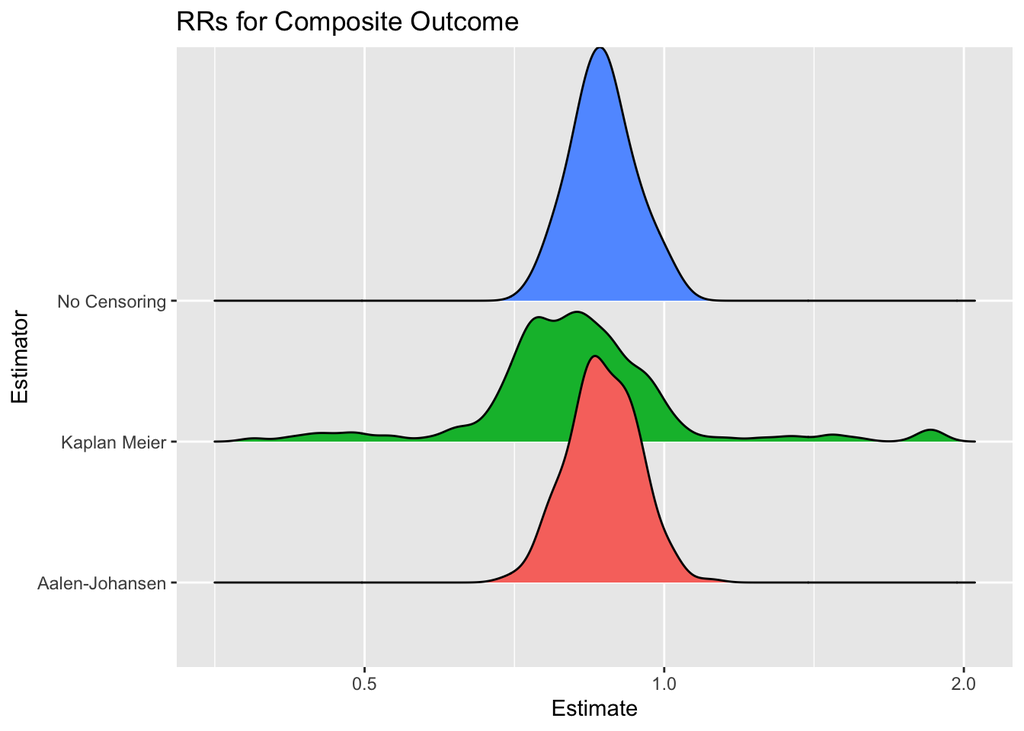

```r
plot_rr(trial, "composite", "RRs for Composite Outcome")
```

Plot of the RRs for SGA, where the AJ estimator only considers Fetal Death as a competing event (i.e., delivery is treated as a censoring event.

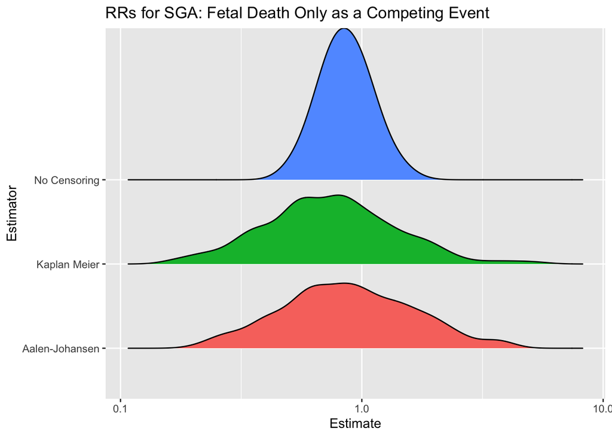

```r
plot_rr(trial, "sga_fd", "RRs for SGA: Fetal Death Only as a Competing Event")
```

Plot of the RRs for SGA, where the AJ estimator considers both fetal death and live birth without SGA as competing events. For simplicity, we have considered these as only 1 competing event.

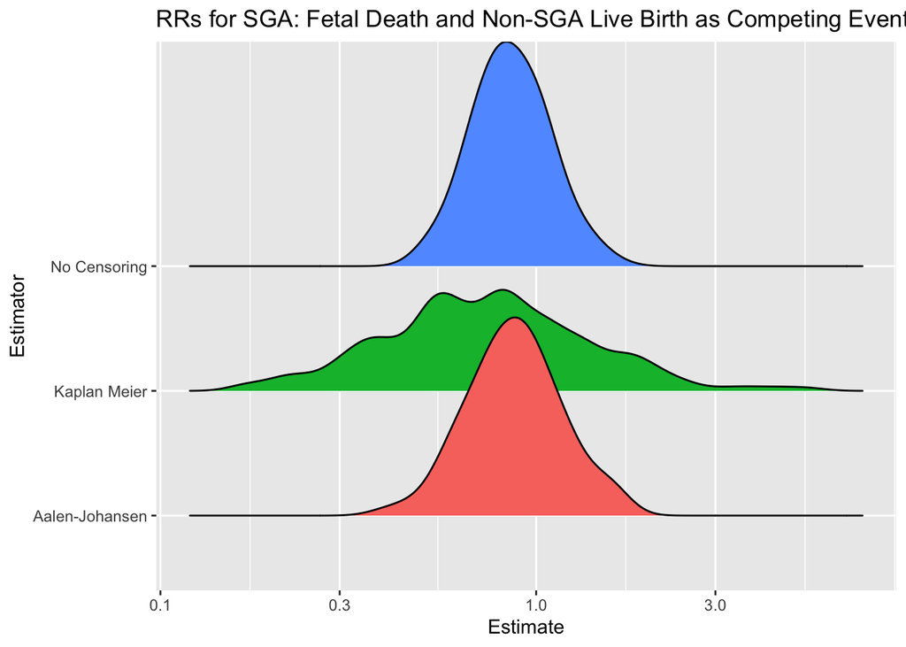

```r
plot_rr(trial, "sga_all", "RRs for SGA: Fetal Death and Non-SGA Live Birth as Competing Events")
```

Plot of the RRs for preterm birth. Fetal death is a competing event. Follow-up stops after 34 gestational weeks.

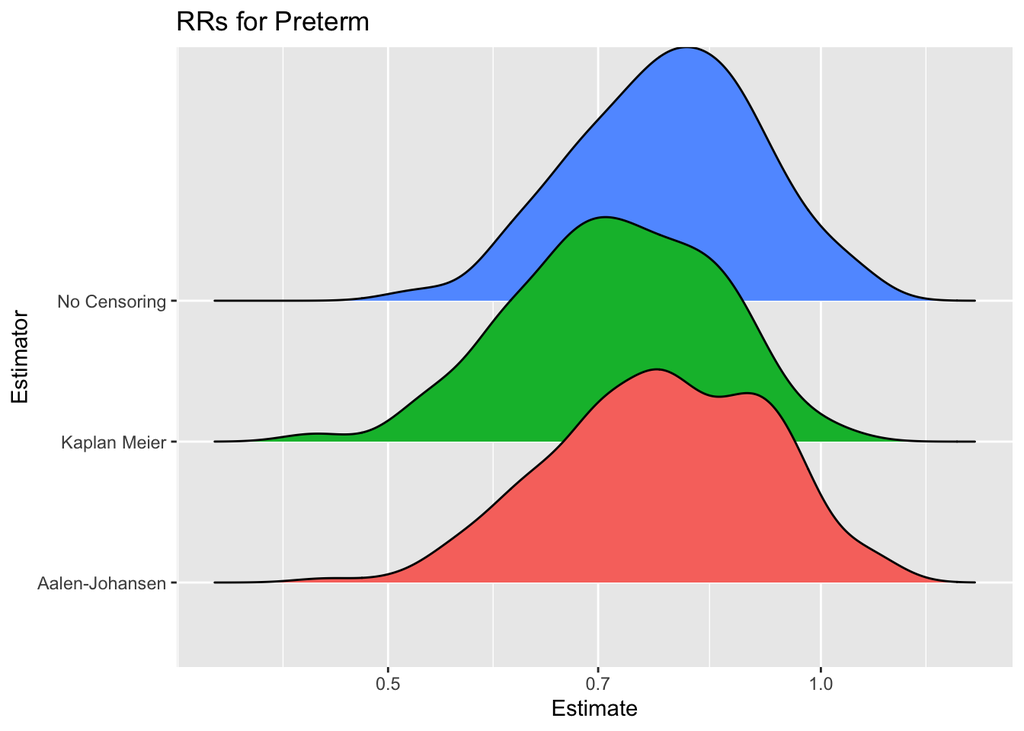

```r
plot_rr(trial, "preterm", "RRs for Preterm")
```

Finally, we print the summary RRs from each of the estimators:

```r
rr_and_rd %>%
  mutate(KM = paste0(round(rr_km,3), " (", round(rr_km_lcl,3), ", ", round(rr_km_ucl,3), ")"),
         AJ = paste0(round(rr_aj,3), " (", round(rr_aj_lcl,3), ", ", round(rr_aj_ucl,3), ")"),
         No_Censoring = paste0(round(rr_nocen,3), " (", round(rr_nocen_lcl,3), ", ",
                               round(rr_nocen_ucl,3), ")")
         ) %>%
  mutate(Outcome = case_when(outcome == "composite" ~ "Composite",
                             outcome == "sga_fd" ~ "SGA: Fetal Death Only",
                             outcome == "sga_all" ~ "SGA: All Competing Events",
                             outcome == "preterm" ~ "Preterm")) %>%
  select(c(Outcome, KM, AJ, No_Censoring)) %>%
  kbl() %>%
  kable_material(c("striped", "hover"))
```

| Outcome | KM | AJ | No_Censoring |
| --- | --- | --- | --- |
| Composite | 0.816 (0.791, 0.843) | 0.868 (0.858, 0.877) | 0.867 (0.859, 0.876) |
| SGA: Fetal Death Only | 0.737 (0.676, 0.804) | 0.875 (0.803, 0.954) | 0.856 (0.828, 0.884) |
| SGA: All Competing Events | 0.737 (0.676, 0.804) | 0.874 (0.84, 0.91) | 0.856 (0.828, 0.884) |
| Preterm | 0.719 (0.703, 0.735) | 0.774 (0.756, 0.793) | 0.782 (0.766, 0.798) |

### RDs

Below is the code for the function plotting RDs for each study outcome.

```r
plot_rd <- function(dataset, outcome_var, title = "") {

  rd_var <- paste0(outcome_var, "_ rd")

  plot <- dataset %>%
    select(
      !!sym(paste0("km_", rd_var)),
      !!sym(paste0("aj_", rd_var)),
      !!sym(paste0("no_censor_", rd_var))
    ) %>%
    pivot_longer(
      names_to = "Estimator",
      cols = c(!!sym(paste0("km_", rd_var)),
               !!sym(paste0("aj_", rd_var)),
               !!sym(paste0("no_censor_", rd_var))),
      values_to = "Estimate"
    ) %>%
    mutate(
      Estimator = case_when(
        Estimator == paste0("km_", rd_var) ~ "Kaplan Meier",
        Estimator == paste0("aj_", rd_var) ~ "Aalen-Johansen",
        Estimator == paste0("no_censor_", rd_var) ~ "No Censoring"
      )
    ) %>%
    ggplot(aes(x = Estimate, y = Estimator, fill = Estimator)) +
    geom_density_ridges() +
    #scale_x_continuous(trans = "log10") +
    theme(legend.position = "none") +
    ggtitle(title)

  # Suppress messages so that we do not see the binwidth message.
  suppressMessages(print(plot))

}
```

Plot of the RDs for the composite outcome.

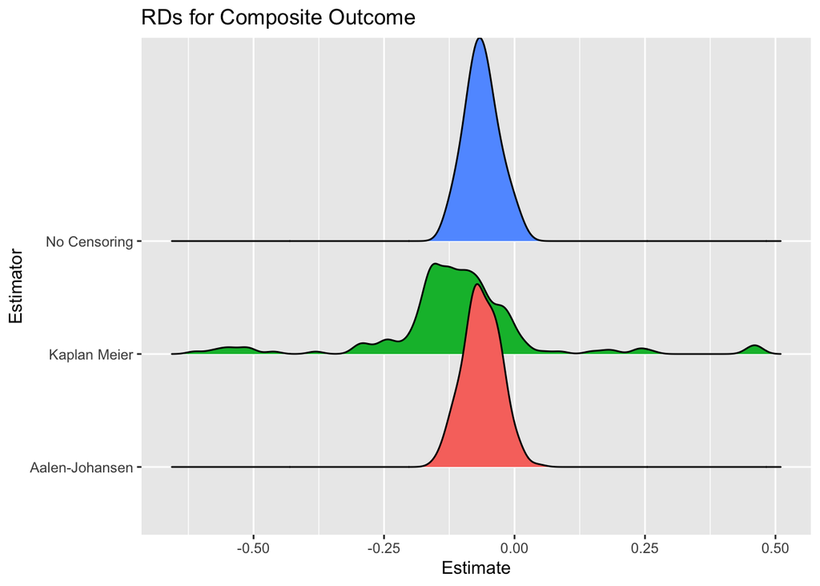

```r
plot_rd(trial, "composite", "RDs for Composite Outcome")
```

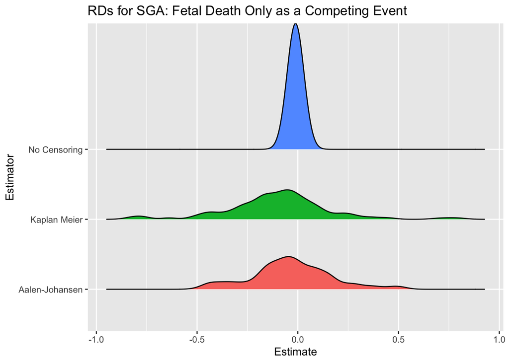

```r
plot_rd(trial, "sga_fd", "RDs for SGA: Fetal Death Only as a Competing Event")
```

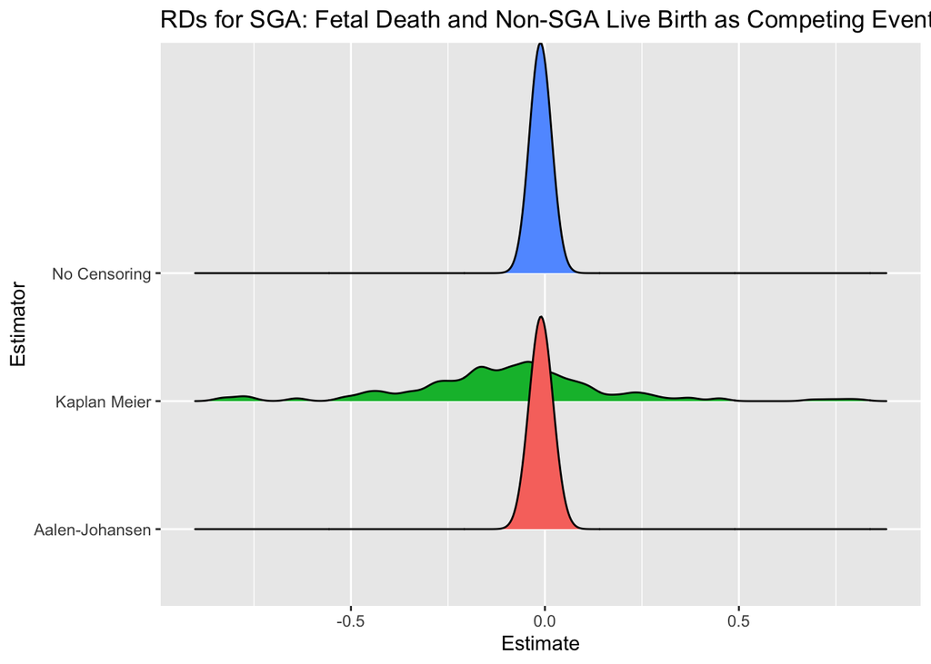

```r
plot_rd(trial, "sga_all", "RDs for SGA: Fetal Death and Non-SGA Live Birth as Competing Events")
```

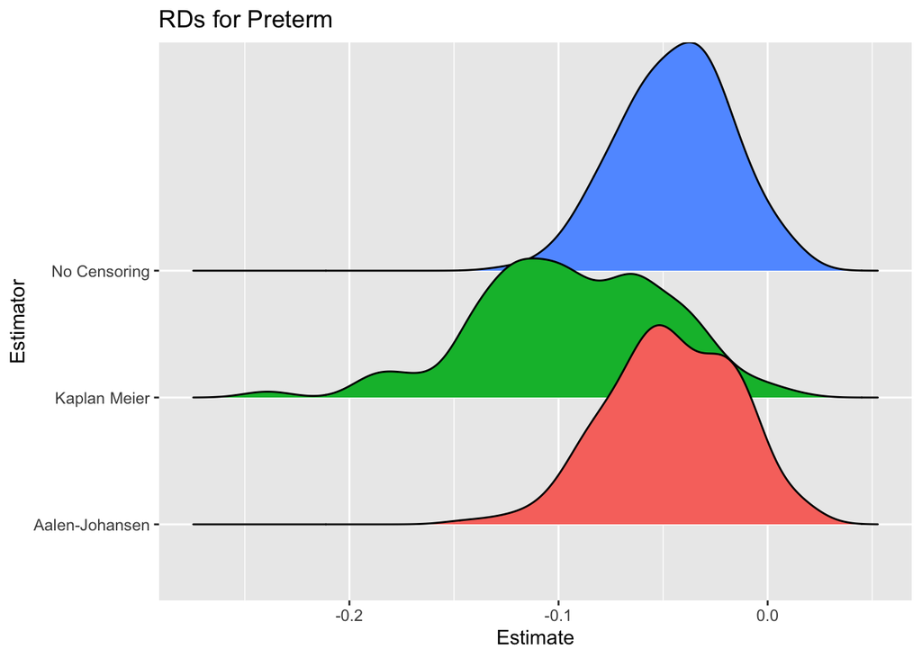

```r
plot_rd(trial, "preterm", "RDs for Preterm")
```

```r
rr_and_rd %>%
  mutate(KM = paste0(round(rd_km,3), " (", round(rd_km_lcl,3), ", ", round(rd_km_ucl,3), ")"),
         AJ = paste0(round(rd_aj,3), " (", round(rd_aj_lcl,3), ", ", round(rd_aj_ucl,3), ")"),
         No_Censoring = paste0(round(rd_nocen,3), " (", round(rd_nocen_lcl,3), ", ",
                               round(rd_nocen_ucl,3), ")")
         ) %>%
  mutate(Outcome = case_when(outcome == "composite" ~ "Composite",
                             outcome == "sga_fd" ~ "SGA: Fetal Death Only",
                             outcome == "sga_all" ~ "SGA: All Competing Events",
                             outcome == "preterm" ~ "Preterm")) %>%
  select(c(Outcome, KM, AJ, No_Censoring)) %>%
  kbl() %>%
  kable_material(c("striped", "hover"))
```

| Outcome | KM | AJ | No_Censoring |
| --- | --- | --- | --- |
| Composite | -0.111 (-0.132, -0.09) | -0.063 (-0.068, -0.058) | -0.063 (-0.067, -0.058) |
| SGA: Fetal Death Only | -0.099 (-0.135, -0.063) | -0.032 (-0.06, -0.005) | -0.011 (-0.013, -0.009) |
| SGA: All Competing Events | -0.099 (-0.135, -0.063) | -0.01 (-0.013, -0.007) | -0.011 (-0.013, -0.009) |
| Preterm | -0.093 (-0.1, -0.087) | -0.046 (-0.05, -0.042) | -0.044 (-0.048, -0.041) |

# Save Files

```r
### Save the file as an RDS file

# Get the directory where the Rmd file is located
rmd_directory <- dirname(rstudioapi::getSourceEditorContext()$path)

# Specify the Excel file name and path relative to the Rmd file location

## We want to save trial2
trial2_save <- file.path(rmd_directory, "trial.rds")
saveRDS(trial2, file = trial2_save)

## And we want to save rr_and_rd
rr_and_rd_save <- file.path(rmd_directory, "rr_and_rd.rds")
saveRDS(rr_and_rd, file = rr_and_rd_save)
```